# Практична робота №6

## Тема: Закони розподілу функцій випадкових величин. Композиція законів розподілу. Розподіл екстремальних значень.

## Мета: Набути практичних навичок у розв’язанні задач з обчислення функцій від випадкових величин, їх законів розподілу та числових характеристик.

## 1. Випадкові величини 𝑋 та 𝑌 незалежні та обидві мають рівномірний закон розподілу з параметрами 𝑎 = 0, 𝑏 = 2. Знайти функції розподілу та щільності розподілу випадкової величини 𝑍 = 𝑋 + 𝑌.

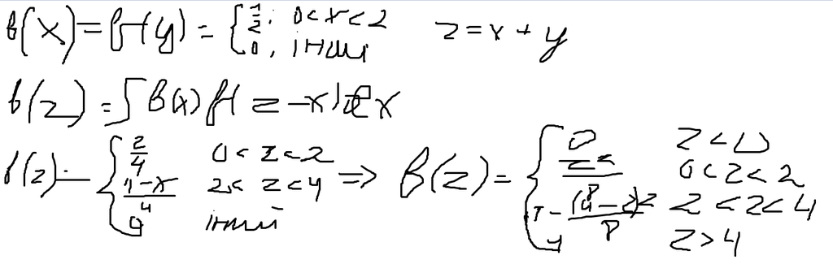

## 2. Час між запитами до серверу комп’ютерної мережі є випадковою величиною 𝑋, що має експоненціальний закон розподілу з параметром 𝜆 = 10. З метою дослідження степені використання серверу необхідно встановити закон розподілу максимумів випадкової величини 𝑋, тобто деякої випадкової величини 𝑍 = 𝑚𝑎𝑥(𝑋).

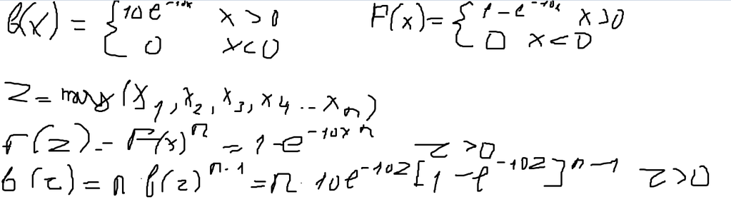

## 3. Випадкова величина 𝑋 має рівномірний розподіл з параметрами 𝑎 = 0, 𝑏 = 𝜋. Знайти функції розподілу та щільності розподілу випадкової величини 𝑍 = 𝑠𝑖𝑛(𝑋), обчислити математичне сподівання 𝑀(𝑍) та дисперсію 𝐷(𝑍)

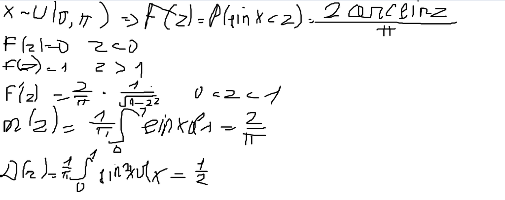

## 4. Випадкова величина 𝑋 має рівномірний розподіл з параметрами 𝑎 = 0, 𝑏 = 𝜋. Знайти функції розподілу та щільності розподілу випадкової величини 𝑍 = 𝑐𝑜𝑠( 𝑋), обчислити математичне сподівання 𝑀(𝑍) та дисперсію 𝐷(𝑍).

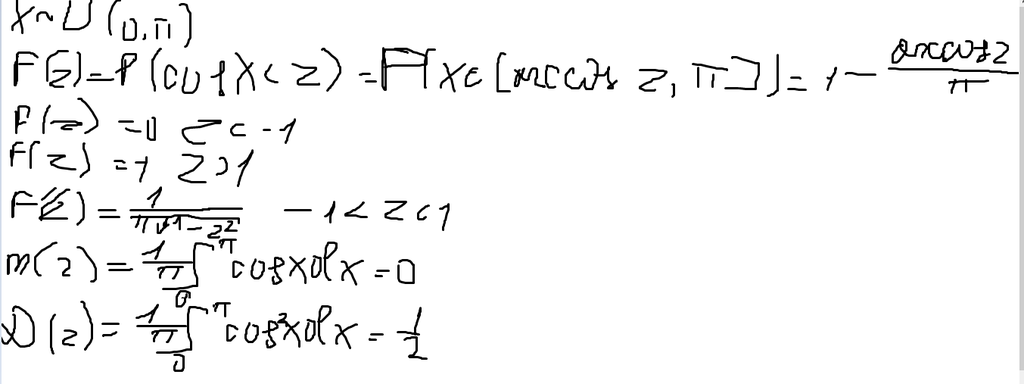

## 5. Час між запитами до серверу комп’ютерної мережі є випадковою величиною 𝑋, що має експоненціальний закон розподілу з параметром 𝜆 = 5. З метою дослідження степені використання серверу необхідно встановити закон розподілу мінімумів випадкової величини 𝑋, тобто деякої випадкової величини 𝑍 = 𝑚𝑖𝑛(𝑋).

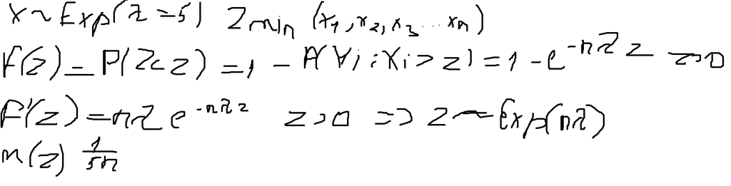

## Контрольні питання

### 1. Знання закону розподілу пікових навантажень у комп’ютерній мережі є дуже важливим для її моделювання та аналізу. Воно дозволяє: Оцінити ймовірність перевантаження мережі, Раціонально планувати ресурси, Підвищити надійність системи, Моделювати реальні робочі умови, Оптимізувати витрати.

### 2. Математичне сподівання функції від випадкової величини знаходять за допомогою закону розподілу X, тобто потрібно знати закон розподілу X (його щільність або ймовірності) і підставити функцію g(x) під знак інтеграла (або суми).

### 3. По суті для дисперсії необхідно знати тільки як треба знаходити мат сподівання, тільки при вирішенні піднести до квадрату.

### 4. Аналіз монотонності функції на етапі знаходження закону розподілу випадкової величини Z=g(X) потрібен, тому що від цього залежить, як саме перетворюється закон розподілу при зміні змінної.

### 5. Час обробки кількох запитів сервером або час проходження деталей через кілька етапів виробництва, аналіз точності приладу або сумарний електричний шум у колі, сумарний дохід або збиток.

## Висновок

### На цій практичній роботі ми познайомилися та навчилися виконувати задачі з випадковими величинами та їх розподілами.